# Module 6: Missing Data

CRP 241 — IVAM-ED Teaching Case

Author

Your Name

Published

July 31, 2026

## Overview

Nine of 112 enrolled participants (8%) did not complete the 12-week follow-up. That is a modest rate — but how we handle those 9 participants can matter. This module examines three approaches to missing outcome data and compares their results.

By the end of this module you should be able to:

1. Describe three missing-data mechanisms (MCAR, MAR, MNAR) and explain why the mechanism matters for analysis.
2. Conduct a complete-case analysis and state its assumptions.
3. Apply a baseline-observation-carried-forward (BOCF) sensitivity analysis.
4. Run a simple multiple-imputation analysis using the `mice` package and pool the results.
5. Interpret how much the estimates change across the three approaches.

## Setup

```r
library(dplyr)
library(mice)     # multiple imputation
library(ggplot2)
```

```r
dat <- readRDS("../data/ivam_working.rds")
```

## 1. Review: Who Is Missing and Why?

```r
# Count missing participants by group and reason
dat |>
  filter(missing_12wk == 1) |>
  count(group_label, reason_missing)
```

```
# A tibble: 4 × 3
  group_label   reason_missing       n
  <fct>         <chr>            <int>
1 Usual care    death                2
2 Usual care    lost_to_followup     3
3 Smart speaker death                1
4 Smart speaker lost_to_followup     3
```

```r
# Compare baseline characteristics between completers and non-completers
dat |>
  mutate(completed = factor(missing_12wk,
                            levels = c(0, 1),
                            labels = c("Completed", "Missing"))) |>
  group_by(completed) |>
  summarise(
    n            = n(),
    srq20_mean   = round(mean(srq20_0), 1),
    srq20_sd     = round(sd(srq20_0),   1),
    hba1c_mean   = round(mean(hba1c_0), 1),
    age_mean     = round(mean(age),     1),
    female_pct   = round(mean(female) * 100, 1)
  )
```

```
# A tibble: 2 × 7
  completed     n srq20_mean srq20_sd hba1c_mean age_mean female_pct
  <fct>     <int>      <dbl>    <dbl>      <dbl>    <dbl>      <dbl>
1 Completed   103        7.2      3.8        7.6     72.2       65
2 Missing       9       15.4      1.4        7.7     75.5       66.7
```

**Note**

**What to notice:** In our simulated data, the missing participants were selected as those with the highest baseline SRQ-20 scores within each group. So participants who dropped out started with higher mental distress on average. This is our MAR mechanism — missingness is related to the observed baseline value, not to the unobserved follow-up value.

## 2. Missing Data Mechanisms

Before choosing an analysis approach, we need to think about *why* data are missing. There are three formal mechanisms:

| Mechanism | Definition | Implication |
| --- | --- | --- |
| **MCAR** (Missing Completely At Random) | Missingness is unrelated to any variable, observed or unobserved | Complete-case analysis is unbiased |
| **MAR** (Missing At Random) | Missingness depends on *observed* variables (e.g., baseline score) but not on the *unobserved* follow-up value | Multiple imputation or mixed models are valid |
| **MNAR** (Missing Not At Random) | Missingness depends on the unobserved follow-up value itself (e.g., those who got worse stopped coming) | No standard analysis is fully valid; sensitivity analyses needed |

In the IVAM-ED protocol, the authors stated: “the frequency and reasons for missing data are expected to be missing at random (MAR).” The three deaths are arguably MCAR (unrelated to the outcome); the six lost-to-follow-up are assumed MAR.

## 3. Analysis 1: Complete-Case Analysis

A **complete-case analysis** uses only the 103 participants with follow-up data and ignores the 9 who are missing. This is what we have been doing in modules 4 and 5. It is the simplest approach.

**Assumption:** The 103 completers are representative of all 112 enrolled participants — or more precisely, that missingness is independent of the follow-up outcome after conditioning on the observed baseline values (MAR).

```r
completers <- filter(dat, missing_12wk == 0)

model_cca <- lm(srq20_12 ~ group + srq20_0, data = completers)

cca_coef <- coef(summary(model_cca))["group", ]
cca_ci   <- confint(model_cca)["group", ]

cat("Complete-case ANCOVA (n = 103):\n")
```

```
Complete-case ANCOVA (n = 103):
```

```r
cat(sprintf("  MD:    %.3f\n",   cca_coef["Estimate"]))
```

```
  MD:    -1.187
```

```r
cat(sprintf("  SE:    %.3f\n",   cca_coef["Std. Error"]))
```

```
  SE:    0.439
```

```r
cat(sprintf("  95%% CI: (%.2f, %.2f)\n", cca_ci[1], cca_ci[2]))
```

```
  95% CI: (-2.06, -0.32)
```

```r
cat(sprintf("  p:     %.4f\n",   cca_coef["Pr(>|t|)"]))
```

```
  p:     0.0081
```

## 4. Analysis 2: Baseline Observation Carried Forward (BOCF)

**BOCF** replaces each missing follow-up value with the participant’s own baseline value. This assumes that participants who dropped out had *no change* from baseline — a conservative assumption that tends to underestimate treatment effects.

The IVAM-ED SAP listed BOCF as one of the pre-specified sensitivity analyses (strategy 2: “a baseline observation carried forward approach”).

```r
# Apply BOCF: if srq20_12 is missing, use srq20_0 as the follow-up value
dat_bocf <- dat |>
  mutate(
    srq20_12_bocf = if_else(is.na(srq20_12), srq20_0, srq20_12)
  )

model_bocf <- lm(srq20_12_bocf ~ group + srq20_0, data = dat_bocf)

bocf_coef <- coef(summary(model_bocf))["group", ]
bocf_ci   <- confint(model_bocf)["group", ]

cat("BOCF ANCOVA (n = 112):\n")
```

```
BOCF ANCOVA (n = 112):
```

```r
cat(sprintf("  MD:    %.3f\n",   bocf_coef["Estimate"]))
```

```
  MD:    -1.200
```

```r
cat(sprintf("  SE:    %.3f\n",   bocf_coef["Std. Error"]))
```

```
  SE:    0.421
```

```r
cat(sprintf("  95%% CI: (%.2f, %.2f)\n", bocf_ci[1], bocf_ci[2]))
```

```
  95% CI: (-2.03, -0.36)
```

```r
cat(sprintf("  p:     %.4f\n",   bocf_coef["Pr(>|t|)"]))
```

```
  p:     0.0053
```

## 5. Analysis 3: Multiple Imputation (MI)

**Multiple imputation** generates several (typically 5–20) plausible complete datasets by drawing imputed values from a model of the missing data, runs the analysis on each complete dataset, and combines the results using Rubin’s rules.

Under MAR, MI is statistically valid and more efficient than BOCF. The IVAM-ED SAP specified MI with baseline data correction as its primary missing-data strategy.

```r
# Variables to include in the imputation model
# Including auxiliary variables (all baselines, demographics) helps MI
# produce better imputations.
vars_for_mi <- dat |>
  select(srq20_12, srq20_0, sf36_12, sf36_0, hba1c_12, hba1c_0,
         sci_r_12, sci_r_0, pss_12, pss_0,
         group, age, female, edu_years, income_wages, mmse_0)

# Run multiple imputation: 5 imputations, 10 iterations
# seed for reproducibility; method "pmm" = predictive mean matching for continuous vars
set.seed(241)
mi_imp <- mice(vars_for_mi, m = 5, maxit = 10, method = "pmm",
               printFlag = FALSE)
```

```r
# Fit the ANCOVA on each imputed dataset and pool the results
mi_fit    <- with(mi_imp, lm(srq20_12 ~ group + srq20_0))
mi_pooled <- pool(mi_fit)

summary(mi_pooled, conf.int = TRUE) |>
  filter(term == "group") |>
  select(term, estimate, std.error, `2.5 %`, `97.5 %`, p.value) |>
  mutate(across(where(is.numeric), \(x) round(x, 3)))
```

```
   term estimate std.error  2.5 % 97.5 % p.value
2 group   -1.171     0.439 -2.045 -0.298   0.009
```

**Note**

**Reading MI output:**

- `estimate`: the treatment effect, averaged (pooled) across all 5 imputed datasets.
- `std.error`: the pooled SE, which accounts for both within-imputation and between-imputation variability.
- `2.5 %` and `97.5 %`: the 95% CI from Rubin’s rules.

Because only 9 participants (8%) are missing, the three approaches should give very similar estimates. Large divergence would signal that the MAR assumption may not hold.

## 6. Comparing the Three Approaches

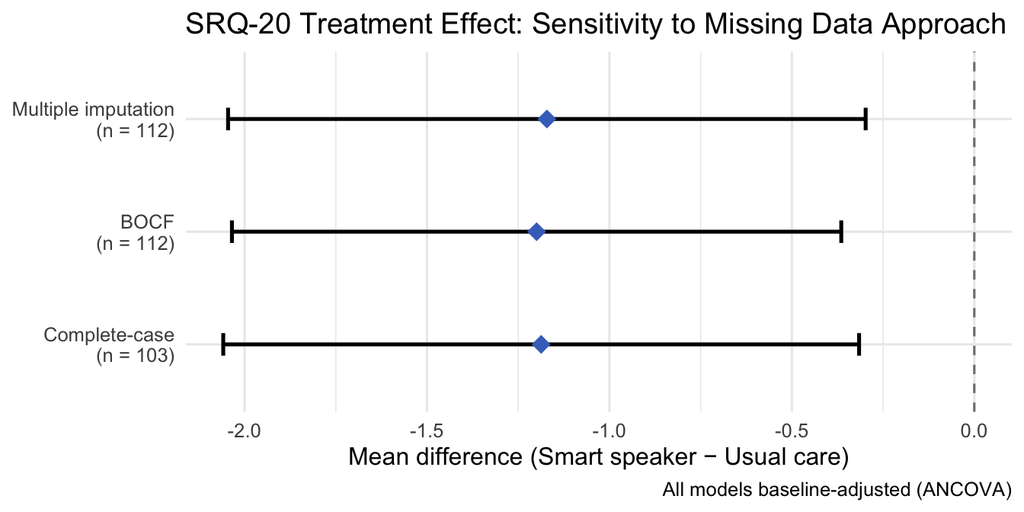

```r
# Gather results from all three analyses
mi_row <- summary(mi_pooled, conf.int = TRUE) |>
  filter(term == "group")

sensitivity <- data.frame(
  Analysis = factor(
    c("Complete-case\n(n = 103)", "BOCF\n(n = 112)", "Multiple imputation\n(n = 112)"),
    levels = c("Complete-case\n(n = 103)", "BOCF\n(n = 112)", "Multiple imputation\n(n = 112)")
  ),
  MD = c(cca_coef["Estimate"],  bocf_coef["Estimate"],  mi_row$estimate),
  lo = c(cca_ci[1],             bocf_ci[1],             mi_row$`2.5 %`),
  hi = c(cca_ci[2],             bocf_ci[2],             mi_row$`97.5 %`)
)

ggplot(sensitivity, aes(x = MD, xmin = lo, xmax = hi, y = Analysis)) +
  geom_vline(xintercept = 0, linetype = "dashed", color = "grey50") +
  geom_errorbarh(height = 0.2, linewidth = 0.9) +
  geom_point(size = 4, shape = 18, color = "#4472C4") +
  labs(
    title   = "SRQ-20 Treatment Effect: Sensitivity to Missing Data Approach",
    x       = "Mean difference (Smart speaker − Usual care)",
    y       = NULL,
    caption = "All models baseline-adjusted (ANCOVA)"
  ) +
  theme_minimal(base_size = 12)
```

**Note**

**What consistent results mean:** If all three estimates point in the same direction and have overlapping confidence intervals, the primary conclusion is **robust to the missing data assumptions**. The published IVAM-ED paper reported that both BOCF and complete-case analyses were consistent with the primary MI analysis, supporting the robustness of the main result.

## 7. Practice Exercises

1. **MCAR vs. MAR.** In Section 1, we saw that missing participants had higher baseline SRQ-20 scores than completers. Does this pattern support MCAR or MAR? Explain in one sentence.
2. **BOCF direction.** If participants who dropped out were getting *worse* (rather than staying the same), would BOCF overestimate or underestimate the treatment effect? Why?
3. **Imputation model variables.** We included all five outcomes’ baseline and follow-up values in the imputation model, plus demographic variables. Why is it generally better to include more variables in the imputation model than fewer?
4. **Compare the three CIs.** Using the forest plot from Section 6, which analysis produces the widest confidence interval? Why? Which produces the narrowest?

## Summary

In this module you:

- Described three missing-data mechanisms and their implications for analysis.
- Conducted a complete-case analysis (the default ANCOVA from Module 5).
- Applied BOCF as a conservative sensitivity analysis.
- Ran a multiple-imputation analysis using the `mice` package and pooled results.
- Confirmed that all three approaches gave consistent conclusions.

**Next:** Module 7 connects the statistical findings back to the published paper — examining clinical significance, the distinction between primary and exploratory findings, and comparing the published analysis to what the protocol and SAP specified.